# Econ 10R Midterm Solutions

# Question 1 (3pts)

1. Load and store the `college.csv` dataset in R. (1pt)

```r
college <- read.csv("college.csv")
```

2. Rename the first column `X` to `College`. (1pt)

```r
colnames(college)[1] <- "College"
```

3. Separate the colleges into private and non-private, each with its own data frame. (1pt)

```r
unique(college$Private)
```

```
## [1] "Yes" "No"
```

```r
college_private <- filter(college, Private == "Yes")
college_nonprivate <- filter(college, Private == "No")
```

# Question 2 (7pts)

1. Find the college with the highest estimated book cost. (1pt)

```r
arrange(college, desc(Books))[1:10, c("College", "Books")]
```

```
##                             College Books
## 1       Center for Creative Studies  2340
## 2                Bradley University  2000
## 3                   Bowdoin College  1495
## 4               Wesleyan University  1400
## 5            University of the Arts  1300
## 6  Rensselaer Polytechnic Institute  1230
## 7  Savannah Coll. of Art and Design  1200
## 8               University of Tulsa  1200
## 9          SUNY College at Purchase  1125
## 10      MidAmerica Nazarene College  1100
```

It is the Center for Creative Studies with 2340 dollars.

2. For both private and non-private colleges, find the one that has the highest percentage of faculty with Ph.D.’s. What is weird about the result? (2pts)

```r
arrange(college_private, desc(PhD))[1:10, c("College", "PhD")]
```

```
##                                  College PhD
## 1                      Bryn Mawr College 100
## 2                    Harvey Mudd College 100
## 3                         Pitzer College 100
## 4                       Brown University  99
## 5              Claremont McKenna College  99
## 6      Hobart and William Smith Colleges  99
## 7  Massachusetts Institute of Technology  99
## 8                  University of Chicago  99
## 9                           Bard College  98
## 10                     Tulane University  98
```

```r
arrange(college_nonprivate, desc(PhD))[1:10, c("College", "PhD")]
```

```
##                                     College PhD
## 1         Texas A&M University at Galveston 103
## 2  New Mexico Institute of Mining and Tech.  99
## 3                University of North Dakota  97
## 4       University of Alabama at Birmingham  96
## 5        University of California at Irvine  96
## 6                  University of Washington  96
## 7                               The Citadel  95
## 8        University of Texas at San Antonio  94
## 9                   George Mason University  93
## 10                Michigan State University  93
```

Several colleges tie for private colleges, and Texas A&M University at Galveston is the highest for non-private. The latter has a percentage that is higher than 100, which is strange.

3. Find the college with the highest and the lowest acceptance rate. (2pts)

```r
college_accept <- mutate(college, AcceptRate = Accept / Apps)
arrange(college_accept, desc(AcceptRate))[1:10, c("College", "Apps", "Accept", "AcceptRate")]
```

```
##                             College Apps Accept AcceptRate
## 1          Emporia State University 1256   1256  1.0000000
## 2         Mayville State University  233    233  1.0000000
## 3       MidAmerica Nazarene College  331    331  1.0000000
## 4      Southwest Baptist University 1093   1093  1.0000000
## 5  University of Wisconsin-Superior  910    910  1.0000000
## 6               Wayne State College 1373   1373  1.0000000
## 7          Arkansas Tech University 1734   1729  0.9971165
## 8    Southwestern Adventist College  321    318  0.9906542
## 9                 Pikeville College  404    400  0.9900990
## 10              Mount Marty College  279    276  0.9892473
```

```r
arrange(college_accept, AcceptRate)[1:10, c("College", "Apps", "Accept", "AcceptRate")]
```

```
##                  College  Apps Accept AcceptRate
## 1   Princeton University 13218   2042  0.1544863
## 2     Harvard University 13865   2165  0.1561486
## 3        Yale University 10705   2453  0.2291453
## 4        Amherst College  4302    992  0.2305904
## 5       Brown University 12586   3239  0.2573494
## 6  Georgetown University 11115   2881  0.2591993
## 7      Dartmouth College  8587   2273  0.2647025
## 8        Duke University 13789   3893  0.2823265
## 9    Columbia University  6756   1930  0.2856720
## 10      Williams College  4186   1245  0.2974200
```

Several colleges tie for the highest acceptance rate. Princeton has the lowest rate.

4. Find the college that has the lowest graduation rate among all colleges with the full word “California” in their names. (2pts)

```r
college_cal <- filter(college, str_detect(College, "California"))
arrange(college_cal, Grad.Rate)[, c("College", "Grad.Rate")]
```

```
##                                 College Grad.Rate
## 1           Southern California College        43
## 2       California Polytechnic-San Luis        59
## 3        California Lutheran University        60
## 4 California State University at Fresno        61
## 5    University of California at Irvine        66
## 6     University of Southern California        68
## 7      St. Mary's College of California        78
## 8  University of California at Berkeley        78
```

It looks like Southern California College has the lowest graduation rate.

# Question 3 (10pts)

1. Load and store the `air.csv` dataset in R. (1pt)

```r
air <- read.csv("air.csv")
```

2. Using information in `date`, generate three variables for each observation: `year`, `month`, `day`. (2pts)

```r
air$date_format <- as.Date(as.character(air$date), format = "%Y%m%d")
air <- mutate(air,
              year = year(date_format),
              month = month(date_format),
              day = day(date_format))
head(select(air, year, month, day))
```

```
##   year month day
## 1 2015     1   2
## 2 2015     1   3
## 3 2015     1   4
## 4 2015     1   5
## 5 2015     1   6
## 6 2015     1   7
```

3. Which station has the highest average AQI (worst air quality) across all dates? (1pt)

```r
arrange(summarise(group_by(air, station), count = n(), average_AQI = mean(AQI, na.rm = TRUE)), desc(average_AQI))[1:10, ]
```

```
## # A tibble: 10 × 3
##    station count average_AQI
##    <chr>   <int>       <dbl>
##  1 2700A     730        260.
##  2 2699A     730        247.
##  3 2702A     730        226.
##  4 2698A     730        224.
##  5 2701A     730        217.
##  6 2695A     730        191.
##  7 2696A     730        185.
##  8 1492A     730        164.
##  9 1304A     730        160.
## 10 1052A     730        152.
```

Clearly station 2700A has the worst average AQI.

4. For each station, find the dates with the best and worst air qualities (indicated by the AQI). Store these observations in a single, new data frame. (2pts)

```r
air_max <- filter(group_by(air, station), AQI == max(AQI, na.rm = TRUE))
air_min <- filter(group_by(air, station), AQI == min(AQI, na.rm = TRUE))
air_extrema <- arrange(rbind(air_max, air_min), station, AQI, year, month, day)[, c("station", "year", "month", "day", "AQI")]
head(air_extrema)
```

```
## # A tibble: 6 × 5
## # Groups:   station [1]
##   station  year month   day   AQI
##   <chr>   <dbl> <dbl> <int> <int>
## 1 1001A    2016    10     8    12
## 2 1001A    2015     2    22   500
## 3 1001A    2015    12    25   500
## 4 1001A    2015    12    30   500
## 5 1001A    2016     1     3   500
## 6 1001A    2016     3     5   500
```

5. What is the relationship between air qualities across two consecutive days? Find the correlation coefficient, and plot the relationship. Bonus point if the graph looks great. (2pts)

```r
air_lag <- mutate(group_by(air, station), AQI_lag = lag(AQI))
air_lag <- filter(air_lag, AQI != "NA" & AQI_lag != "NA")
cor(air_lag$AQI, air_lag$AQI_lag)
```

```
## [1] 0.5770228
```

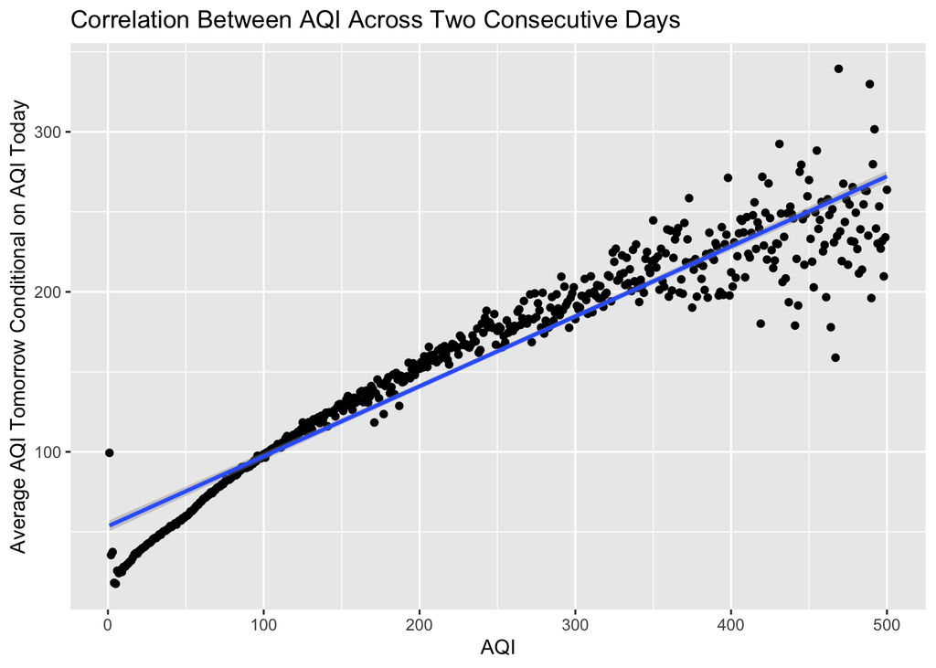

```r
air_lag <- summarise(group_by(air_lag, AQI_lag),
                          AQI_mean = mean(AQI))
ggplot(data = air_lag, aes(x = AQI_lag, y = AQI_mean)) +
  geom_point() +
  geom_smooth(method = lm) +
  labs(title = "Correlation Between AQI Across Two Consecutive Days",
       x = "AQI", y = "Average AQI Tomorrow Conditional on AQI Today")
```

6. For each unique date, find the station with the highest index of each of the six pollutants (note that this does not include `AQI`). Store the data in a data frame with the format where each date is an observation, each pollutant a variable, and the values of the variables are the station number. If there are multiple stations with the same index for the same pollutant on the same day, just pick whichever one you want as the value for that variable. (2pts)

```r
air_six <- group_by(air, year, month, day)
air_six_CO <- arrange(filter(air_six, CO_24h == max(CO_24h, na.rm = TRUE)), year, month, day)
air_six_NO2 <- arrange(filter(air_six, NO2_24h == max(NO2_24h, na.rm = TRUE)), year, month, day)
air_six_O3 <- arrange(filter(air_six, O3_24h == max(O3_24h, na.rm = TRUE)), year, month, day)
air_six_PM10 <- arrange(filter(air_six, PM10_24h == max(PM10_24h, na.rm = TRUE)), year, month, day)
air_six_PM2.5 <- arrange(filter(air_six, PM2.5_24h == max(PM2.5_24h, na.rm = TRUE)), year, month, day)
air_six_SO2 <- arrange(filter(air_six, SO2_24h == max(SO2_24h, na.rm = TRUE)), year, month, day)

air_six_CO <- select(air_six_CO[!duplicated(air_six_CO$date), ], station, date, year, month, day, CO_24h)
air_six_CO <- mutate(air_six_CO, pollu = "CO")
air_six_NO2 <- select(air_six_NO2[!duplicated(air_six_NO2$date), ], station, date, year, month, day, NO2_24h)
air_six_NO2 <- mutate(air_six_NO2, pollu = "NO2")
air_six_O3 <- select(air_six_O3[!duplicated(air_six_O3$date), ], station, date, year, month, day, O3_24h)
air_six_O3 <- mutate(air_six_O3, pollu = "O3")
air_six_PM10 <- select(air_six_PM10[!duplicated(air_six_PM10$date), ], station, date, year, month, day, PM10_24h)
air_six_PM10 <- mutate(air_six_PM10, pollu = "PM10")
air_six_PM2.5 <- select(air_six_PM2.5[!duplicated(air_six_PM2.5$date), ], station, date, year, month, day, PM2.5_24h)
air_six_PM2.5 <- mutate(air_six_PM2.5, pollu = "PM2.5")
air_six_SO2 <- select(air_six_SO2[!duplicated(air_six_SO2$date), ], station, date, year, month, day, SO2_24h)
air_six_SO2 <- mutate(air_six_SO2, pollu = "SO2")
air_six <- select(arrange(rbind(air_six_CO, air_six_NO2, air_six_O3, air_six_PM10, air_six_PM2.5, air_six_SO2), date), year, month, day, station, pollu)

head(pivot_wider(air_six, names_from = "pollu", values_from = "station"))
```

```
## # A tibble: 6 × 9
## # Groups:   year, month, day [6]
##    year month   day CO    NO2   O3    PM10  PM2.5 SO2
##   <dbl> <dbl> <int> <chr> <chr> <chr> <chr> <chr> <chr>
## 1  2015     1     2 2475A 1910A 1332A 1628A 1495A 1485A
## 2  2015     1     3 2475A 2667A 1976A 2690A 2552A 1087A
## 3  2015     1     4 1912A 2667A 1366A 1079A 2667A 1087A
## 4  2015     1     5 2475A 1303A 2487A 1055A 1054A 2184A
## 5  2015     1     6 2475A 2386A 2669A 1075A 1818A 1485A
## 6  2015     1     7 2475A 2667A 2189A 2700A 1330A 2184A
```